# Fall 2019 Lab Rotation Simulation

Jiayi (Jessie) Tong

10/20/2019

### Aim of this file

This R markdown file is written to simulate the single-cell data to demonstrate if the order of the batch when applying mutual nearest neighbors (MNN) would affect the clustering results.

### Simulation Design

In this simulation study, we are going to simulate four different batches to mimic the temporal from week 0 to week 24. As time goes on, the observed cell population increases. In Figure 1, we present the idea of the simulated data. In each batch, there are different numbers of cell populations: 3, 4, 5, and 7. There exist batch effects among the cell populations 1, 2, 3, 4 and 5 across four batches.

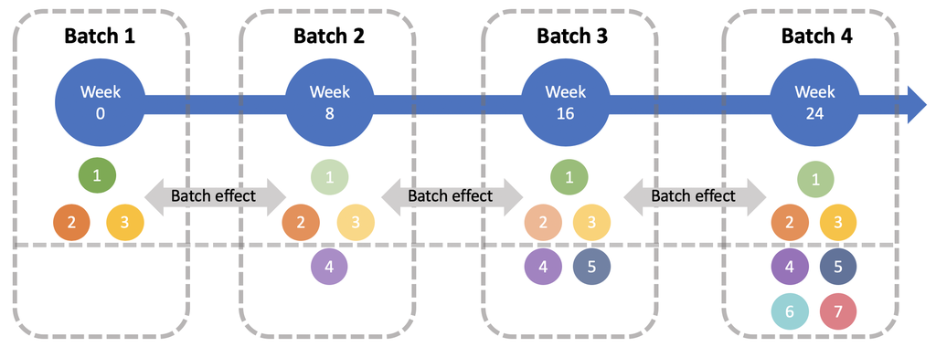

Figure 1

### R package to be used: Symsim

To simulate the data, we are going to use Symsim package, which is one most recently published R package for simulating multiple faceted variability in single cell RND sequencing data.

```r
# Install SymSim
library("devtools")
# devtools::install_github('YosefLab/SymSim')
```

#### 0. Original

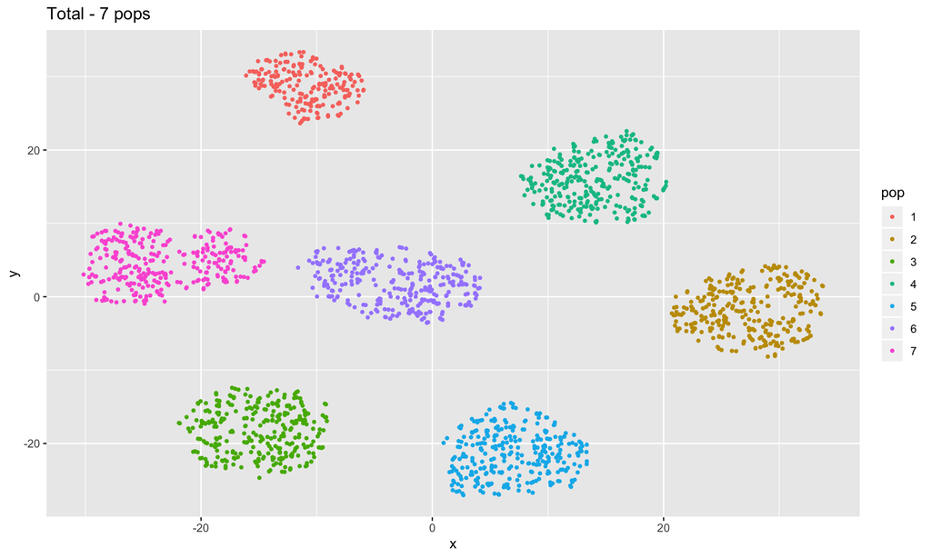

```r
library("SymSim")
###########
ngenes = 1000
true_counts_res <- SimulateTrueCounts(ncells_total=2000,
                                      min_popsize=200, #number of cells in the rarest population
                                      randseed = 0, # random seed to reproduce the results
                                      ngenes=ngenes, # number of genes
                                      phyla=rtree(7),
                                      evf_type="discrete",
                                      scale_s = 0.9,
                                      nevf=30,
                                      Sigma=0.1,
                                      n_de_evf=10)

tsne_true_counts <- PlotTsne(meta=true_counts_res[[3]],
                             data=log2(true_counts_res[[1]]+1),
                             evf_type="discrete",
                             n_pc=20, label='pop',
                             saving = F,
                             plotname="Total - 7 pops")

# plot of true counts with 7 different cells population
tsne_true_counts[[2]]
```

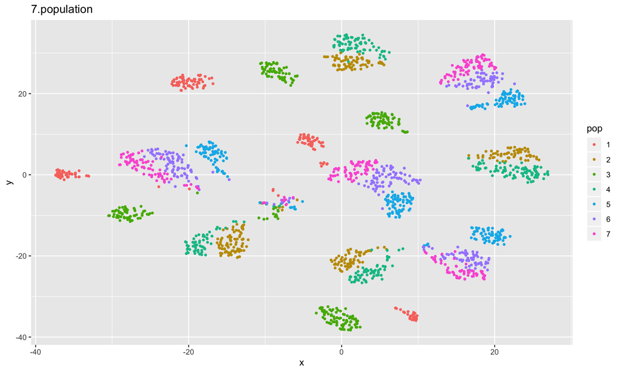

```r
# extract cell-meta from true_counts_res
cell_meta = true_counts_res$cell_meta

# Pooled data: check the number of cells in each population
table(cell_meta[,2])

data(gene_len_pool)
gene_len <- sample(gene_len_pool[which(gene_len_pool < 200)], ngenes, replace = FALSE)

# Start the clock! -----------------------------
ptm <- proc.time()

observed_counts <- True2ObservedCounts(true_counts=true_counts_res[[1]],
                                       meta_cell=true_counts_res[[3]],
                                       protocol="nonUMI",
                                       alpha_mean=0.1,
                                       alpha_sd=0.05,
                                       gene_len=gene_len,
                                       depth_mean=1e5,
                                       depth_sd=3e3,
                                       nbatch = 4)

# Stop the clock ----------------------------
proc.time() - ptm

# plot the combined population from four different batches
PlotTsne(meta=observed_counts[[2]],
         data=log2(observed_counts[[1]]+1),
         evf_type="7.population",
         n_pc=20,
         label='pop',
         saving = F,
         plotname="7.population")[[2]]
```

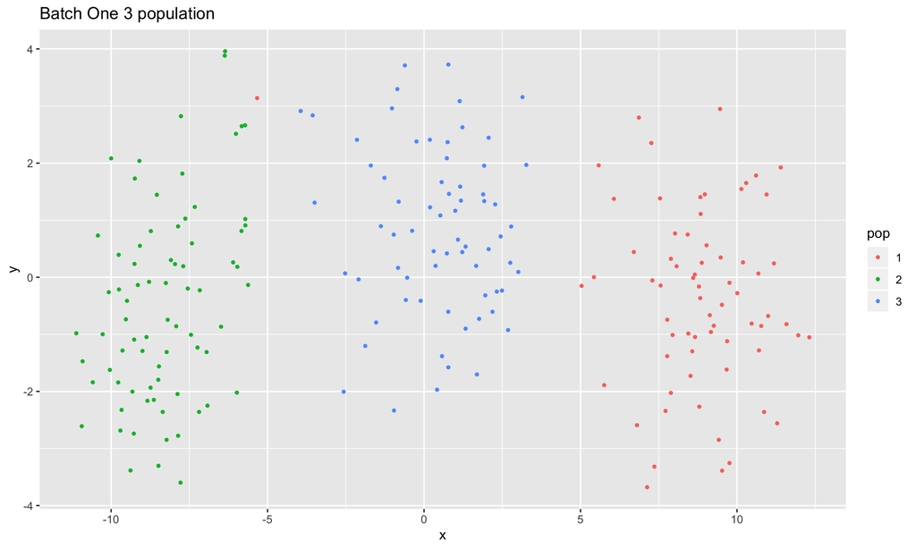

```r
# funtion to divide the batch and population based on the combined data
batch_divider <- function(batch_id, batch_name, size_batch_num){

  # extract the batch with batch_id from the whole population
  batch_id = which(observed_counts[[2]]$batch == batch_id)

  # based on the id, extract the cell meta
  batch_observed_cell_meta = observed_counts[[2]][batch_id,]

  # print the cell meta information
  batch_cell_meta_dim = dim(batch_observed_cell_meta)

  # based on the id, extract the observed counts
  batch_observed_counts = observed_counts[[1]][,batch_id]

  # print the count information
  batch_count_dim = dim(batch_observed_counts)

  # extract the batch with size_batch_num:
  # e.g., batch 1 has three pop, batch 2 has 4 pop, batch 3 has 5 pop, batch 4 has 7 pop
  batch_sub_id = batch_observed_cell_meta$pop %in% c(1:size_batch_num)

  # based on the batch sub id, extract the cell meta
  batch_observed_cell_meta_sub = batch_observed_cell_meta[batch_sub_id,]

  # print the cell meta sub information
  batch_cell_meta_dim_sub = dim(batch_observed_cell_meta_sub)

  # based on the sub id, extract the observed counts
  batch_observed_counts_sub = batch_observed_counts[,batch_sub_id]

  # print the counbt information
  batch_count_dim_sub = dim(batch_observed_counts_sub)

  # plot the cells population, subgroup 3 populations
  tsne_true_counts = PlotTsne(meta=batch_observed_cell_meta_sub,
                              data=log2(batch_observed_counts_sub+1),
                              evf_type=paste("Batch", batch_name, size_batch_num,"population"),
                              n_pc=20,
                              label='pop',
                              saving = F,
                              plotname=paste("Batch", batch_name, size_batch_num,"population"))

  return(list(tsne = tsne_true_counts,
              batch_observed_cell_meta_sub = batch_observed_cell_meta_sub,
              batch_cell_meta_dim_sub = batch_cell_meta_dim_sub,
              batch_observed_counts_sub = batch_observed_counts_sub,
              batch_count_dim_sub = batch_count_dim_sub))
}

########################################
# Bacth one: with three cell populations
batch1 = batch_divider(batch_id = 1,
                       batch_name = "One",
                       size_batch_num = 3)
# plot
batch1$tsne[[2]]
```

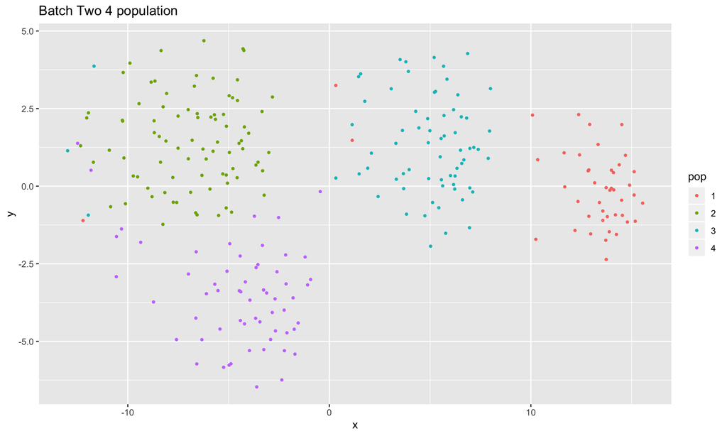

```r
# calculate the proportion of each population
round(table(batch1$batch_observed_cell_meta_sub[,2])/
  sum(table(batch1$batch_observed_cell_meta_sub[,2])),2)

########################################
# Bacth two: with four cell populations
batch2 = batch_divider(batch_id = 2,
                       batch_name = "Two",
                       size_batch_num = 4)
batch2$tsne[[2]]
```

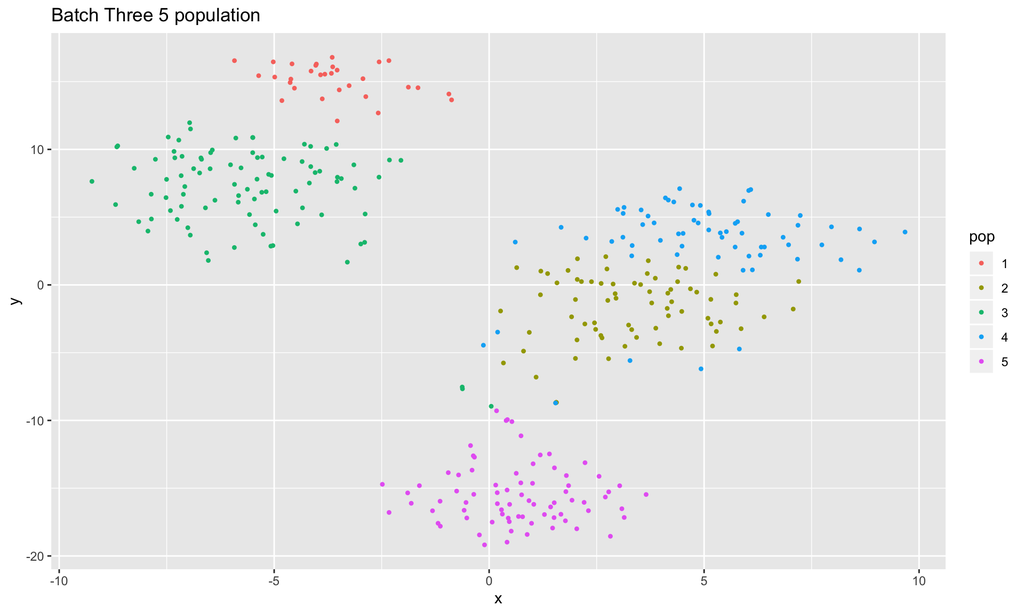

```r
# calculate the proportion of each population
round(table(batch2$batch_observed_cell_meta_sub[,2])/
        sum(table(batch2$batch_observed_cell_meta_sub[,2])),2)

########################################
# Bacth three: with five cell populations
batch3 = batch_divider(batch_id = 3,
                       batch_name = "Three",
                       size_batch_num = 5)
batch3$tsne[[2]]
```

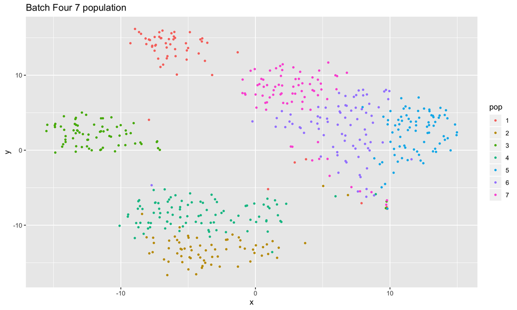

```r
# calculate the proportion of each population
round(table(batch3$batch_observed_cell_meta_sub[,2])/
        sum(table(batch3$batch_observed_cell_meta_sub[,2])),2)

########################################
# Bacth four: with seven cell populations
batch4 = batch_divider(batch_id = 4,
                       batch_name = "Four",
                       size_batch_num = 7)
batch4$tsne[[2]]
```

```r
# calculate the proportion of each population
round(table(batch4$batch_observed_cell_meta_sub[,2])/
        sum(table(batch4$batch_observed_cell_meta_sub[,2])),2)
```

### References:

Haghverdi, Laleh, et al. “Batch effects in single-cell RNA-sequencing data are corrected by matching mutual nearest neighbors.” Nature biotechnology 36.5 (2018): 421.

Zhang, Xiuwei, Chenling Xu, and Nir Yosef. “Simulating multiple faceted variability in single cell RNA sequencing.” Nature communications 10.1 (2019): 2611.